# Japan life tables

Tue, 05 Nov 2013

[Japan](http://flothesof.github.io/tag/japan.html) [statistics](http://flothesof.github.io/tag/statistics.html)

I recently watched this [Vice video on Youtube](http://www.youtube.com/watch?v=qpZbu7J7UL4) which is a coverage about the Japanese sex industry. Except for the fact that it looks like it was made with a message in mind that ressembles "the Japanese are weird", it cited government surveys about the population of Japan declining. Given that I have been interested in data relating to death statistics and more generally statistics about populations, I decided to examine the Japanese age pyramid.

In this endeavour, the first step was to gather the right data. I was able to find life tables for Japan at the [Ministry of Health, Labor and Welfare website](http://www.mhlw.go.jp/english/database/db-hw/lifetb21th/dl/tables.pdf).

In this article, I'm going to be working on the data for Japanese men. The linked file contains two interesting things:

- the number of surviving people in an hypothetical cohort of 100000 people starting as babies
- the probability of dying at a given age (death rate)

```python
data = """Age,number of survivors,number of deaths,survivors rate,death rate,force of mortality,life expectancy,stationary L,stationary T
0,100000,246,0.99754,0.00246,0.09375,79.55,99808,7955005
1,99754,37,0.99963,0.00037,0.00057,78.75,99733,7855198
2,99716,26,0.99974,0.00026,0.00026,77.78,99704,7755464
3,99690,18,0.99982,0.00018,0.00022,76.80,99681,7655761
4,99672,13,0.99987,0.00013,0.00015,75.81,99665,7556080
5,99659,11,0.99989,0.00011,0.00012,74.82,99653,7456415
6,99647,10,0.99990,0.00010,0.00011,73.83,99642,7356762
7,99637,9,0.99991,0.00009,0.00010,72.84,99632,7257120
8,99628,8,0.99992,0.00008,0.00009,71.84,99623,7157488
9,99619,8,0.99992,0.00008,0.00008,70.85,99615,7057865
10,99612,8,0.99992,0.00008,0.00008,69.85,99608,6958249
11,99603,10,0.99990,0.00010,0.00009,68.86,99599,6858642
12,99594,11,0.99989,0.00011,0.00010,67.87,99588,6759043
13,99583,13,0.99987,0.00013,0.00012,66.87,99577,6659454
14,99570,15,0.99985,0.00015,0.00014,65.88,99563,6559878
15,99555,19,0.99981,0.00019,0.00017,64.89,99546,6460315
16,99536,24,0.99976,0.00024,0.00021,63.90,99525,6360769
17,99512,30,0.99970,0.00030,0.00027,62.92,99498,6261244
18,99482,37,0.99962,0.00038,0.00034,61.94,99464,6161746
19,99445,44,0.99955,0.00045,0.00041,60.96,99423,6062282
20,99401,51,0.99949,0.00051,0.00048,59.99,99376,5962859
21,99350,57,0.99943,0.00057,0.00055,59.02,99322,5863483
22,99293,61,0.99939,0.00061,0.00060,58.05,99262,5764162
23,99232,63,0.99936,0.00064,0.00063,57.09,99200,5664899
24,99169,64,0.99936,0.00064,0.00064,56.12,99137,5565699
25,99105,64,0.99936,0.00064,0.00064,55.16,99073,5466562
26,99041,64,0.99935,0.00065,0.00065,54.19,99009,5367489
27,98977,66,0.99934,0.00066,0.00066,53.23,98944,5268480
28,98911,67,0.99933,0.00067,0.00067,52.26,98878,5169536
29,98845,68,0.99932,0.00068,0.00068,51.30,98811,5070658
30,98777,68,0.99931,0.00069,0.00069,50.33,98743,4971847
31,98709,70,0.99929,0.00071,0.00070,49.37,98674,4873104
32,98638,73,0.99926,0.00074,0.00073,48.40,98602,4774431
33,98565,76,0.99923,0.00077,0.00076,47.44,98527,4675829
34,98489,80,0.99919,0.00081,0.00079,46.48,98449,4577302
35,98409,84,0.99915,0.00085,0.00083,45.51,98367,4478853
36,98325,89,0.99910,0.00090,0.00088,44.55,98281,4380486
37,98236,96,0.99902,0.00098,0.00094,43.59,98188,4282205
38,98139,106,0.99892,0.00108,0.00103,42.63,98087,4184017
39,98034,115,0.99882,0.00118,0.00113,41.68,97977,4085929
40,97918,126,0.99872,0.00128,0.00123,40.73,97857,3987952
41,97793,137,0.99860,0.00140,0.00134,39.78,97725,3890096
42,97656,149,0.99848,0.00152,0.00146,38.83,97583,3792370
43,97508,162,0.99834,0.00166,0.00159,37.89,97428,3694788
44,97346,176,0.99819,0.00181,0.00173,36.95,97259,3597360
45,97170,192,0.99802,0.00198,0.00189,36.02,97075,3500100
46,96978,210,0.99784,0.00216,0.00207,35.09,96875,3403025
47,96768,231,0.99762,0.00238,0.00227,34.17,96655,3306151
48,96538,254,0.99737,0.00263,0.00250,33.25,96413,3209496
49,96284,278,0.99711,0.00289,0.00276,32.33,96147,3113083
50,96006,304,0.99683,0.00317,0.00303,31.42,95856,3016936
51,95702,332,0.99653,0.00347,0.00332,30.52,95538,2921080
52,95370,363,0.99619,0.00381,0.00364,29.63,95191,2825542
53,95006,398,0.99581,0.00419,0.00400,28.74,94810,2730351
54,94608,436,0.99539,0.00461,0.00440,27.86,94393,2635541
55,94172,478,0.99493,0.00507,0.00485,26.98,93936,2541148
56,93694,523,0.99442,0.00558,0.00534,26.12,93436,2447212
57,93171,570,0.99388,0.00612,0.00586,25.26,92890,2353776
58,92601,620,0.99331,0.00669,0.00642,24.42,92295,2260886
59,91981,673,0.99268,0.00732,0.00701,23.58,91649,2168591
60,91308,739,0.99190,0.00810,0.00773,22.75,90944,2076941
61,90568,804,0.99112,0.00888,0.00853,21.93,90172,1985997
62,89764,862,0.99039,0.00961,0.00929,21.12,89338,1895826
63,88902,922,0.98963,0.01037,0.01003,20.32,88446,1806488
64,87980,986,0.98879,0.01121,0.01083,19.53,87492,1718042
65,86994,1056,0.98786,0.01214,0.01172,18.74,86472,1630549
66,85938,1134,0.98681,0.01319,0.01273,17.97,85378,1544077
67,84804,1216,0.98566,0.01434,0.01385,17.20,84203,1458699
68,83588,1298,0.98447,0.01553,0.01503,16.44,82946,1374496
69,82290,1386,0.98315,0.01685,0.01629,15.70,81605,1291551
70,80904,1490,0.98158,0.01842,0.01775,14.96,80168,1209946
71,79413,1607,0.97977,0.02023,0.01947,14.23,78620,1129778
72,77807,1732,0.97773,0.02227,0.02143,13.51,76952,1051158
73,76074,1876,0.97534,0.02466,0.02367,12.81,75149,974206
74,74199,2043,0.97247,0.02753,0.02636,12.12,73192,899057
75,72156,2228,0.96913,0.03087,0.02955,11.45,71058,825865
76,69928,2432,0.96522,0.03478,0.03328,10.79,68730,754807
77,67496,2645,0.96081,0.03919,0.03759,10.16,66192,686077
78,64851,2866,0.95580,0.04420,0.04249,9.56,63436,619885
79,61985,3083,0.95026,0.04974,0.04802,8.98,60461,556449
80,58902,3279,0.94432,0.05568,0.05407,8.42,57278,495988
81,55622,3453,0.93792,0.06208,0.06056,7.89,53910,438711
82,52169,3619,0.93063,0.06937,0.06780,7.38,50374,384801
83,48550,3783,0.92207,0.07793,0.07629,6.89,46672,334427
84,44767,3918,0.91248,0.08752,0.08618,6.43,42817,287756
85,40849,3997,0.90215,0.09785,0.09717,6.00,38854,244938
86,36852,3990,0.89173,0.10827,0.10871,5.59,34853,206085
87,32862,3919,0.88074,0.11926,0.12062,5.21,30894,171231
88,28943,3802,0.86865,0.13135,0.13362,4.85,27031,140337
89,25141,3646,0.85497,0.14503,0.14839,4.51,23303,113307
90,21495,3448,0.83959,0.16041,0.16615,4.19,19752,90003
91,18047,3171,0.82431,0.17569,0.18378,3.89,16436,70252
92,14876,2855,0.80805,0.19195,0.20290,3.62,13421,53816
93,12021,2515,0.79078,0.20922,0.22364,3.36,10734,40395
94,9506,2163,0.77245,0.22755,0.24614,3.12,8395,29661
95,7343,1813,0.75305,0.24695,0.27056,2.90,6407,21266
96,5529,1479,0.73256,0.26744,0.29704,2.69,4763,14859
97,4051,1171,0.71095,0.28905,0.32578,2.49,3441,10096
98,2880,898,0.68823,0.31177,0.35695,2.31,2410,6655
99,1982,665,0.66440,0.33560,0.39077,2.14,1632,4245
100,1317,475,0.63949,0.36051,0.42746,1.98,1065,2613
101,842,325,0.61351,0.38649,0.46726,1.84,669,1548
102,517,214,0.58652,0.41348,0.51044,1.70,402,879
103,303,134,0.55858,0.44142,0.55729,1.58,231,478
104,169,80,0.52977,0.47023,0.60811,1.46,126,247
105,90,45,0.50020,0.49980,0.66325,1.35,65,121
106,45,24,0.46998,0.53002,0.72307,1.25,32,56
107,21,12,0.43925,0.56075,0.78796,1.16,14,24
108,9,5,0.40818,0.59182,0.85837,1.07,6,10
109,4,2,0.37696,0.62304,0.93474,0.99,2,4
110,1,1,0.34578,0.65422,1.01761,0.92,1,1"""
```

First, let's set up our pylab environment.

```python
%pylab inline
rcParams['figure.figsize'] = (10, 4)
```

Now, let's read the data displayed above to a numpy array:

```python
data = data.split('\n')[1:]
```

```python
data = array([elem.split(',') for elem in data], dtype=np.double)
```

```python
data.shape
```

```
(111, 9)
```

First, let's plot the survivors as a function of their age.

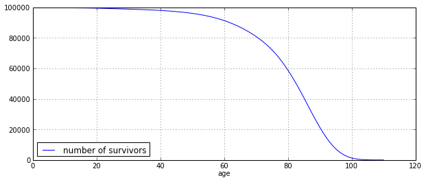

```python
plot(data[:, 0], data[:, 1], label = "number of survivors")
legend(loc='lower left')
xlabel('age')
grid(True)
```

Now, let's plot the death rate.

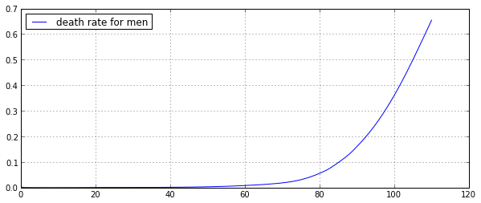

```python
plot(data[:, 0], data[:, 4], label = "death rate for men")
legend(loc='upper left')
grid(True)
```

From there, we can build a simple model of an evolving population. The state equation we're going to use is the following (adapted from http://en.wikipedia.org/wiki/Demographic_analysis): $$ P_{new} = P_{old} + B - D $$

where $P$ is the population number, $B$ is the number of births and $D$ the number of deaths. We will describe the population by a vector $P = P_i$ containing the respective population numbers for age $i$, i.e. $P_{12}$ is the population aged between 12 and 13. For each iteration, $P_0$ gets incremented by the number of births while all other age groups $i$ get decremented by $P_i * d_i$ where $d_i$ is the death probability for the age group in question.

Looking for the birth rates, I found the following figure [here](http://www.mhlw.go.jp/english/database/db-hw/populate/dl/02.pdf) for the year 2011: 8.3 children per 1000 population per year. We will ignore the infant and neonatal death rates for this figure.

Looking for the current age pyramid, I found the following [link](http://www.e-stat.go.jp/SG1/estat/ListE.do?lid=000001112823). Unfortunately, it does not provide a very fine grained population pyramid, therefore I'll be interpolating it linearly on one year age categories for the following simulation.

First, let's do the data formatting.

```python
age_data_men = """0	529000
1	543000
2	529000
3	529000
4	544000
5	2746000
10	2983000
15	3068000
20	3117000
25	3495000
30	3889000
35	4712000
40	4727000
45	4077000
50	3802000
55	3917000
60	4997000
65	3914000
70	3426000
75	2730000
80	1822000
85	899000
90	265000
95	60000
100	7000"""

age_data_men = array([elem.split('\t') for elem in age_data_men.split('\n')], dtype=np.int32)
```

We'll use the following approach for interpolation. First, we'll build a function that returns the number of people above a given age. Second, we'll build a function that gives the number of people in an age interval by substracting two numbers from the previous function.

```python
def population_above(age, age_data=age_data_men):
    """returns population above age
    """
    if age >= age_data[-1, 0]:
        return age_data[-1, 1]
    index = (age_data[:, 0] >= age).nonzero()[0][0]
    if age_data[index, 0] == age:
        return sum(age_data[index:, 1])
    else:
        return sum(age_data[index:, 1]) + (age_data[index, 0] - age) / float(age_data[index, 0] - age_data[index - 1, 0]) * age_data[index - 1, 1]
```

```python
def population_between(start, end, age_data=age_data_men):
    """returns population between start and end ages
    start and end are expected to be integers"""
    return population_above(start, age_data=age_data) - population_above(end, age_data=age_data)
```

We can now test this function.

```python
print population_between(0, 1), 529000
print population_between(1, 2), 543000
print population_between(5, 10), 2746000
print population_between(5, 15), (2746000 + 2983000)
print population_between(5, 6), (2746000 / 5.)
print population_between(10, 11), (2983000 / 5.)
print population_between(5, 11), (2746000 + 2983000 / 5.)
print population_between(9, 10), (2746000 / 5.)
```

```
529000 529000
543000 543000
2746000 2746000
5729000 5729000
549200.0 549200.0
596600.0 596600.0
3342600.0 3342600.0
549200.0 549200.0
```

From there, we can construct the age pyramid for men.

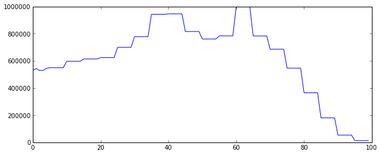

```python
ages = arange(100)
pyramid = [population_between(age, age + 1) for age in ages]
plot(ages, pyramid)
```

Just a quick check:

```python
print sum(pyramid), sum(age_data_men[:, 1])
```

```
61320000.0 61327000
```

We can now iterate the simulation using the curve of death probability and the birth data. In the next cell, we're defining a function that constructs a new age pyramid from an old pyramid taking into account deaths and births.

```python
def construct_new_pyramid(old_pyramid, death_probs, birth_rate):
    births = birth_rate / 1000 * sum(old_pyramid)
    new_pyramid = old_pyramid * (1 - death_probs)
    new_pyramid[-2] += new_pyramid[-1]
    new_pyramid[1:] = new_pyramid[0:-1]
    new_pyramid[0] = births
    return new_pyramid
```

```python
death_probs = data[:, 4][:ages.shape[0]]
```

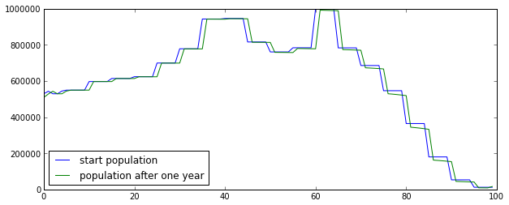

```python
plot(ages, pyramid, label='start population')
plot(ages, construct_new_pyramid(pyramid, death_probs, 8.3), label='population after one year')
legend(loc='lower left')
```

As one can see, the population shifts to the right, while newborn babies are added to the left of the plot. We can iterate this behavious several times to construct estimates in the future for the years 2023, 2033 and 2043.

```python
def iterate_pyramid(pyramid, death_probs, birth_rate, years):
    for year in range(years):
        pyramid = construct_new_pyramid(pyramid, death_probs, birth_rate)
    return pyramid
```

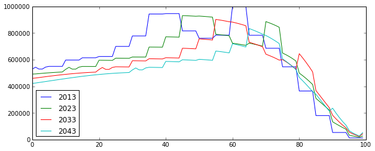

```python
plot(ages, pyramid, label='2013')
plot(ages, iterate_pyramid(pyramid, death_probs, 8.3, 10), label='2023')
plot(ages, iterate_pyramid(pyramid, death_probs, 8.3, 20), label='2033')
plot(ages, iterate_pyramid(pyramid, death_probs, 8.3, 30), label='2043')
legend(loc='lower left')
```

We can also plot population estimates according to this simulation model for one hundred years in the future:

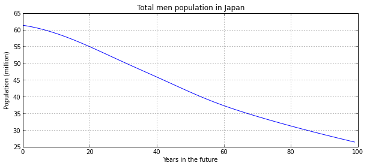

```python
future_years = arange(100)
total_men_population = [sum(iterate_pyramid(pyramid, death_probs, 8.3, future_year)) for future_year in future_years]
plot(future_years, array(total_men_population) / 1e6)
title('Total men population in Japan')
xlabel('Years in the future')
ylabel('Population (million)')
grid(True)
```

As one can see, there is no convergence, only steady decline. This is due to the fact that the birth rate is given per 1000 people. Thus, when the total population declines, the number of births declines and so on. This is better seen on a 1000 year outlook, where the population goes to zero in the long run:

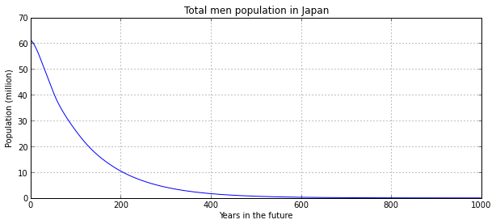

```python
future_years = arange(1000)
total_men_population = [sum(iterate_pyramid(pyramid, death_probs, 8.3, future_year)) for future_year in future_years]
plot(future_years, array(total_men_population) / 1e6)
title('Total men population in Japan')
xlabel('Years in the future')
ylabel('Population (million)')
grid(True)
```

This article has been tagged with the following terms:

[Japan](http://flothesof.github.io/tag/japan.html) [statistics](http://flothesof.github.io/tag/statistics.html)

[figure not shown]